# Research Stuff

# TODO: REVER A MÉTRICA DE CONTAMINAÇAO

# Perguntas!

Quais as perguntas que já foram respondidas?

- Como medir a performance de um jogador (e de um grupo de jogadores) na partida
- Como medir a contaminação tóxica de um time de jogadores em uma partida?
  - Através do número de reports, assumindo que os reports indicam que um determinado jogador sentiu-se incomodado o suficiente pelo jogador tóxico ao ponto de realizar uma denúncia
  - O fato do denunciante ter incluído um texto especificando a motivação de sua denúncia pode significar mais um fator para incuirmos no futuro no calculo da contaminação tóxica.
- Quais os diferentes topicos de conversa utilizados por times de League of legends?
  - Tactics, tactics/pos, small talk, arguments, complaints, insults and taunts
  - Esses padrões podem ser agrupados em dois grupos: um para tópicos positivos (tactics, tactics/pos, small talk) e outro para tópicos negativos (arguments, complaints, insults e taunts)
- Esses topicos relacionam-se de algum modo com a contaminação tóxica e a performance? Se sim, qual a relação?
  - Sim, os tópicos positivos no geral correlacinam-se inversamente com a contaminação, e positivamente com a performance, enquanto tópicos negativos corelacionam-se de maneira positiva com a contaminação, e de maneira negativa com a performance.
- Os tópicos utilizados pelo jogador tóxico influenciam a contaminação de algum modo? Se sim, como?
  - Sim, os tópicos negativos utilizados pelo jogador tóxico influenciam a contaminação, afetando os times de maneiras distintas. Enquanto o time aliado é mais disposto a sofrer efeitos negativos de complaints e insultos feitos pelo jogador tóxico, o time inimigo é mais propenso a sofrer efeitos negativos de taunts.

## Comparação de jogadores não contaminados com os outros jogadores

As we want to show the characteristics of contamined players, we need to define what is a non-contamined player, so that we can compare them. All matches on our dataset have toxic players, so we can’t determine for sure that there is a fully non-contaminated player. However, we can assume that there are groups with virtual no contamination. We chose to use as sample of non-contaminated groups, enemy groups with zero contamination, as enemy groups have a much more limited contact with the offender, and the zero contamination shows that no player in that group was severely affected by the offender’s actions. We found that, from the total of groups, 22.3% of are non-contaminated.

### Distribuição:

Percentage of non-contaminated players from the total of enemy groups.

```r
nrow(groups[relation.offender=='enemy' & contamination == 0])*100/nrow(groups[relation.offender=='enemy'])
```

```
## [1] 66.99673
```

Percentage of non-contaminated players from the total of groups.

```r
nrow(groups[relation.offender=='enemy' & contamination == 0])*100/nrow(groups)
```

```
## [1] 22.33224
```

## Comparação de médias:

#### Não contaminados vs. contaminados:

Non-contaminated groups also presents higher average performance $(mean=0.120, sd=0.02)$ than contaminated groups $(mean=0.086,sd=0.03)$.

```r
med.t.test(groups[relation.offender=='enemy' & contamination == 0]$performance,
                     groups[relation.offender!='enemy' | contamination > 0]$performance)
```

```
## [1] "mean/sd x"
## [1] 0.1204023
## [1] 0.02679578
## [1] "mean/sd y"
## [1] 0.08636324
## [1] 0.03794691
```

```
##
##  Welch Two Sample t-test
##
## data:  x and not_x
## t = 1160.3, df = 2984600, p-value < 2.2e-16
## alternative hypothesis: true difference in means is not equal to 0
## 95 percent confidence interval:
##  0.03398157 0.03409656
## sample estimates:
##  mean of x  mean of y
## 0.12040231 0.08636324
```

#### Não Contaminados vs. inimigos contaminados:

Non-contaminated groups also present higher average performance $(mean=0.120, sd=0.02)$ than contaminated $(mean=0.107, sd=0.03)$ enemy groups.

```r
med.t.test(groups[relation.offender=='enemy' & contamination == 0]$performance,
                     groups[relation.offender=='enemy' & contamination > 0]$performance)
```

```
## [1] "mean/sd x"
## [1] 0.1204023
## [1] 0.02679578
## [1] "mean/sd y"
## [1] 0.1078593
## [1] 0.0342237
```

```
##
##  Welch Two Sample t-test
##
## data:  x and not_x
## t = 258.56, df = 1051300, p-value < 2.2e-16
## alternative hypothesis: true difference in means is not equal to 0
## 95 percent confidence interval:
##  0.01244796 0.01263812
## sample estimates:
## mean of x mean of y
## 0.1204023 0.1078593
```

#### Não Contaminados vs. Aliados contaminados:

And higher average performance $(mean=0.120, sd=0.02)$ than ally groups $(mean=0.084, sd=0.03)$ as well.

```r
med.t.test(groups[relation.offender=='enemy' & contamination == 0]$performance,
                     groups[relation.offender=='ally']$performance)
```

```
## [1] "mean/sd x"
## [1] 0.1204023
## [1] 0.02679578
## [1] "mean/sd y"
## [1] 0.08435106
## [1] 0.03088467
```

```
##
##  Welch Two Sample t-test
##
## data:  x and not_x
## t = 1122.4, df = 3069900, p-value < 2.2e-16
## alternative hypothesis: true difference in means is not equal to 0
## 95 percent confidence interval:
##  0.0359883 0.0361142
## sample estimates:
##  mean of x  mean of y
## 0.12040231 0.08435106
```

#### Inimigos Contaminados vs. Aliados (performance):

We can also compare contaminated enemy groups and ally groups, and confirm that contaminated enemy groups $(mean=0.107, sd=0.03)$ have higher average peformance than allies$(mean=0.08, sd=0.03)$.

```r
med.t.test(groups[relation.offender=='enemy' & contamination > 0]$performance,
                     groups[relation.offender=='ally']$performance)
```

```
## [1] "mean/sd x"
## [1] 0.1078593
## [1] 0.0342237
## [1] "mean/sd y"
## [1] 0.08435106
## [1] 0.03088467
```

```
##
##  Welch Two Sample t-test
##
## data:  x and not_x
## t = 490.9, df = 1018900, p-value < 2.2e-16
## alternative hypothesis: true difference in means is not equal to 0
## 95 percent confidence interval:
##  0.02341435 0.02360207
## sample estimates:
##  mean of x  mean of y
## 0.10785927 0.08435106
```

#### Inimigos Contaminados vs. Aliados (contaminação):

Finnaly, comparing the contamination index of contaminated enemy groups and ally groups, we see that the contaminated enemy groups $(mean=0.28, sd=0.15)$ still are less contaminated than the allies $(mean=0.30, sd=0.21)$ but with a small difference.

```r
med.t.test(groups[relation.offender=='enemy' & contamination > 0]$contamination,
                     groups[relation.offender=='ally']$contamination)
```

```
## [1] "mean/sd x"
## [1] 0.285968
## [1] 0.1556121
## [1] "mean/sd y"
## [1] 0.2999964
## [1] 0.2185822
```

```
##
##  Welch Two Sample t-test
##
## data:  x and not_x
## t = -56.476, df = 1549800, p-value < 2.2e-16
## alternative hypothesis: true difference in means is not equal to 0
## 95 percent confidence interval:
##  -0.0145153 -0.0135416
## sample estimates:
## mean of x mean of y
## 0.2859680 0.2999964
```

T-test’s $p$ is $2.2*10^{16}$, for all these comparisons.

## Topic presence per topic category(Positive and Negative):

```r
prop.table(summary(groups[topic.2=='neg']$topic))
```

```
##   arguments   chit.chat  complaints     insults other.langs   provoking
##  0.30222061  0.00000000  0.43723664  0.16102268  0.00000000  0.09952007
##     tactics tactics.pos
##  0.00000000  0.00000000
```

```r
prop.table(summary(groups[relation.offender=='enemy' & contamination==0]$topic))
```

```
##   arguments   chit.chat  complaints     insults other.langs   provoking
##  0.04146142  0.16235640  0.05441426  0.02493645  0.03086135  0.01523189
##     tactics tactics.pos        NA's
##  0.24795509  0.42084238  0.00194076
```

```r
prop.table(summary(groups[relation.offender=='enemy' & contamination > 0]$topic))
```

```
##   arguments   chit.chat  complaints     insults other.langs   provoking
##  0.12328649  0.17740440  0.08191528  0.02530204  0.02480359  0.03237908
##     tactics tactics.pos        NA's
##  0.20637150  0.32458245  0.00395518
```

```r
prop.table(summary(groups[relation.offender=='ally']$topic))
```

```
##   arguments   chit.chat  complaints     insults other.langs   provoking
## 0.157733101 0.105907638 0.194747578 0.053420594 0.034603955 0.031560371
##     tactics tactics.pos        NA's
## 0.207584003 0.212035295 0.002407466
```

```r
prop.table(summary(groups[relation.offender=='offender']$topic))
```

```
##   arguments   chit.chat  complaints     insults other.langs   provoking
##  0.14708260  0.09423955  0.28180649  0.12040642  0.02761634  0.07046894
##     tactics tactics.pos        NA's
##  0.15325838  0.08225722  0.02286405
```

### Full Dataset:

```
##   arguments   chit.chat  complaints     insults other.langs   provoking
##  12.4427355  12.2489973  18.0014855   6.6294707   3.0360797   4.0973444
##     tactics tactics.pos        NA's
##  19.8357843  22.7788657   0.9292369
```

### Positive Topics:

```
##   arguments   chit.chat  complaints     insults other.langs   provoking
##     0.00000    22.32625     0.00000     0.00000     0.00000     0.00000
##     tactics tactics.pos
##    36.15469    41.51905
```

### Negative Topics:

```
##   arguments   chit.chat  complaints     insults other.langs   provoking
##   30.222061    0.000000   43.723664   16.102268    0.000000    9.952007
##     tactics tactics.pos
##    0.000000    0.000000
```

### Topic presence per groups:

Non-Contaminated:

```
##       neg       pos      NA's
## 13.604401 83.115387  3.280211
```

Contaminated Enemies:

```
##       neg       pos      NA's
## 26.288288 70.835835  2.875877
```

Enemies:

```
##       neg       pos      NA's
## 17.790499 79.062733  3.146768
```

Allies:

```
##       neg       pos      NA's
## 43.746164 52.552694  3.701142
```

Offenders:

```
##      neg      pos     NA's
## 61.97644 32.97552  5.04804
```

## Relationship between topics and groups(Performance):

### Funções:

### Positive topics:

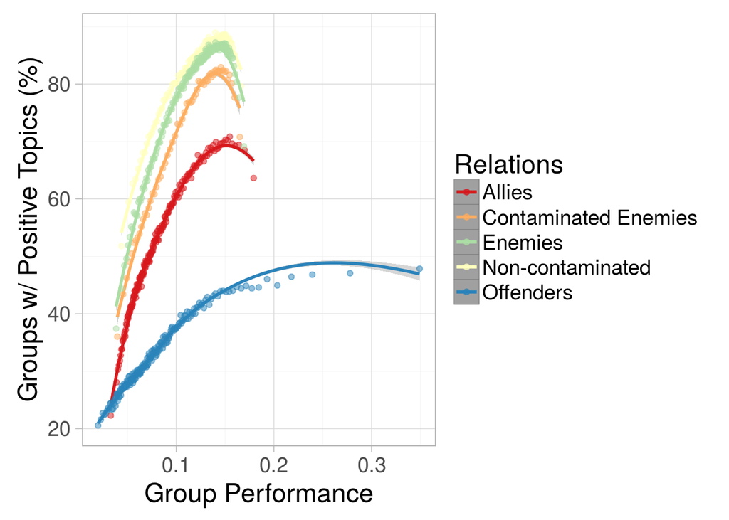

#### Correlações:

```
## [1] "Aliados:"
## [1] 0.9680895
## [1] "Inimigos Contaminados:"
## [1] 0.8432692
## [1] "Não Contaminados:"
## [1] 0.8046749
## [1] "Inimigos Totais:"
## [1] 0.7980725
## [1] "Ofensor:"
## [1] 0.9546973
```

### Tactics-related(tactics + tactics.pos):

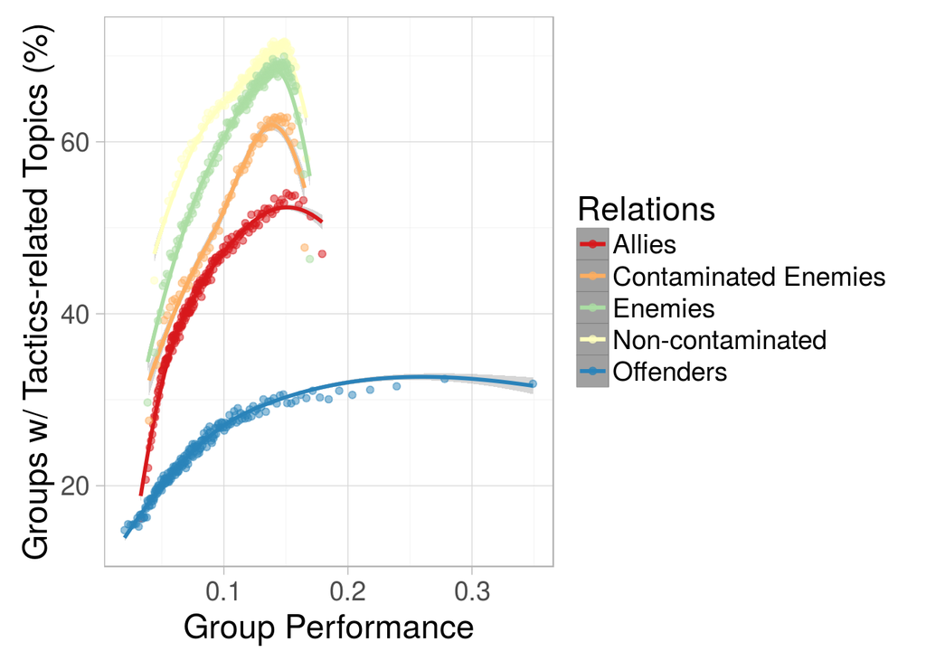

#### Correlações:

```
## [1] "Aliados:"
## [1] 0.9513276
## [1] "Inimigos Contaminados:"
## [1] 0.8192308
## [1] "Não Contaminados:"
## [1] 0.7640866
## [1] "Inimigos Totais:"
## [1] 0.7681547
## [1] "Ofensor:"
## [1] 0.9363036
```

### Mood-related(tactics.pos + small talk):

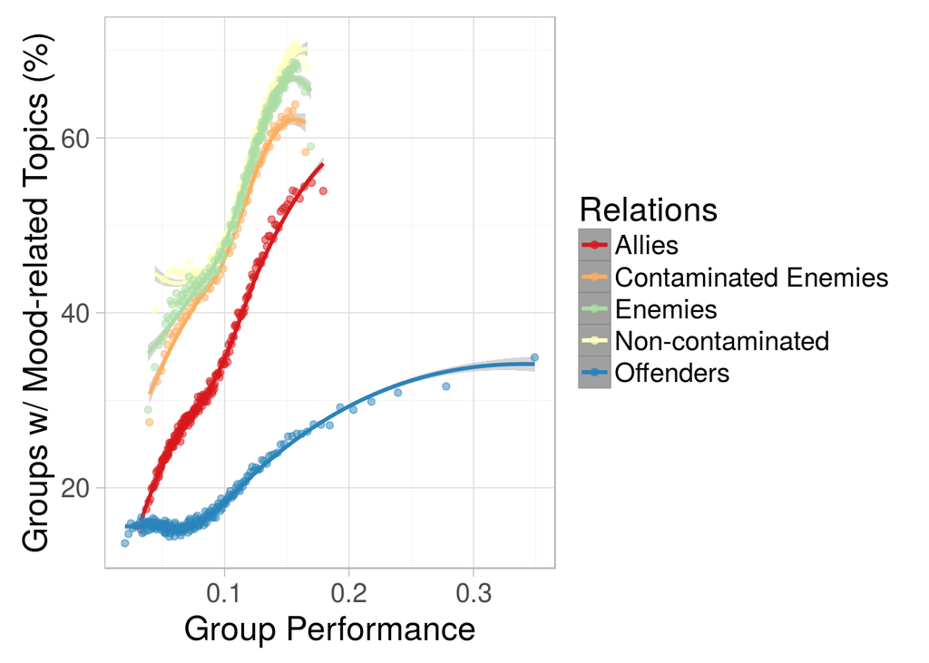

#### Correlações:

```
## [1] "Aliados:"
## [1] 0.9633967
## [1] "Inimigos Contaminados:"
## [1] 0.95
## [1] "Não Contaminados:"
## [1] 0.9501938
## [1] "Inimigos Totais:"
## [1] 0.942106
## [1] "Ofensor:"
## [1] 0.6135424
```

#### Comparações:

##### Performance:

Non-contaminated:

```
## [1] "mean/sd x"
## [1] 0.1242648
## [1] 0.02529473
## [1] "mean/sd y"
## [1] 0.1149968
## [1] 0.02785384
```

```
##
##  Welch Two Sample t-test
##
## data:  x and not_x
## t = 195.14, df = 1103700, p-value < 2.2e-16
## alternative hypothesis: true difference in means is not equal to 0
## 95 percent confidence interval:
##  0.009174971 0.009361142
## sample estimates:
## mean of x mean of y
## 0.1242648 0.1149968
```

Contaminated enemy:

```
## [1] "mean/sd x"
## [1] 0.1144905
## [1] 0.03257593
## [1] "mean/sd y"
## [1] 0.1013424
## [1] 0.03450893
```

```
##
##  Welch Two Sample t-test
##
## data:  x and not_x
## t = 157.35, df = 641980, p-value < 2.2e-16
## alternative hypothesis: true difference in means is not equal to 0
## 95 percent confidence interval:
##  0.01298425 0.01331180
## sample estimates:
## mean of x mean of y
## 0.1144905 0.1013424
```

Ally:

```
## [1] "mean/sd x"
## [1] 0.09301305
## [1] 0.03316181
## [1] "mean/sd y"
## [1] 0.0802906
## [1] 0.02886421
```

```
##
##  Welch Two Sample t-test
##
## data:  x and not_x
## t = 260.46, df = 1081600, p-value < 2.2e-16
## alternative hypothesis: true difference in means is not equal to 0
## 95 percent confidence interval:
##  0.01262671 0.01281818
## sample estimates:
##  mean of x  mean of y
## 0.09301305 0.08029060
```

Offender:

```
## [1] "mean/sd x"
## [1] 0.08960535
## [1] 0.0496235
## [1] "mean/sd y"
## [1] 0.08019803
## [1] 0.04079133
```

```
##
##  Welch Two Sample t-test
##
## data:  x and not_x
## t = 104.11, df = 455250, p-value < 2.2e-16
## alternative hypothesis: true difference in means is not equal to 0
## 95 percent confidence interval:
##  0.009230225 0.009584416
## sample estimates:
##  mean of x  mean of y
## 0.08960535 0.08019803
```

### Negative Topics:

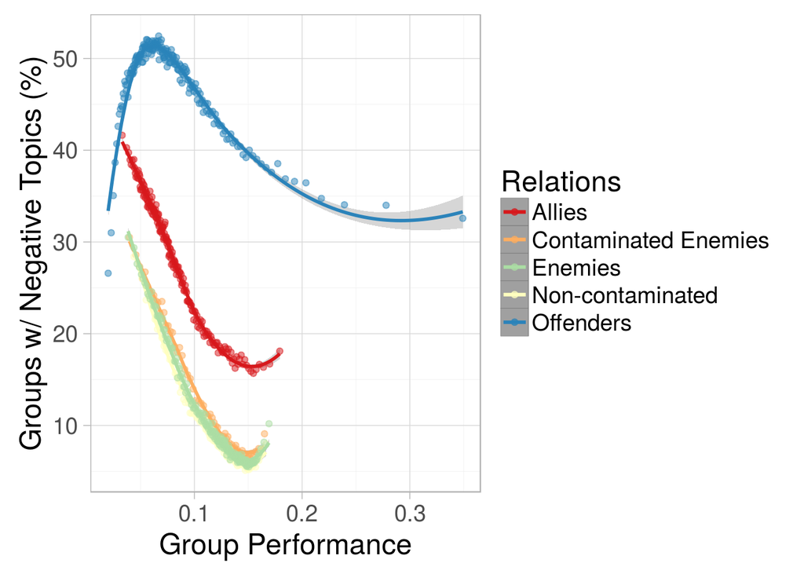

#### Correlações:

```
## [1] "Aliados:"
## [1] -0.9518999
## [1] "Inimigos Contaminados:"
## [1] -0.916787
## [1] "Não Contaminados:"
## [1] -0.8778429
## [1] "Inimigos Totais:"
## [1] -0.8826654
## [1] "Ofensor:"
## [1] -0.3573428
```

```
## [1] "For performance < 0.06:"
```

```
## [1] 0.8339901
```

```
## [1] "For performance >= 0.06:"
```

```
## [1] -0.8853053
```

### Arguments:

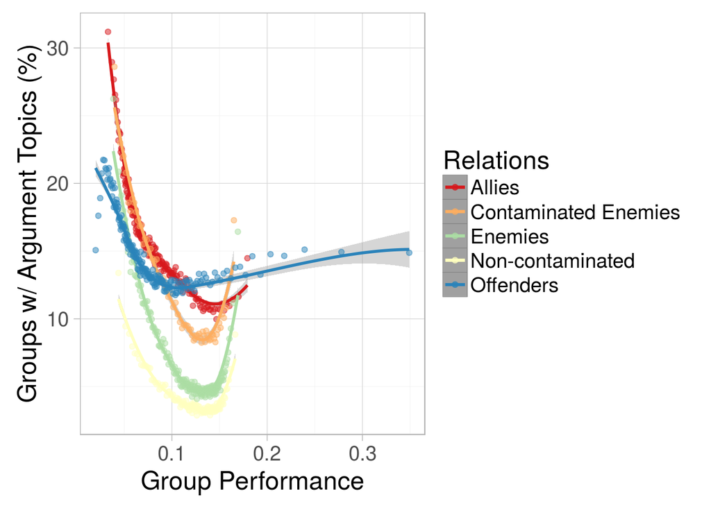

#### Correlações:

```
## [1] "Aliados:"
## [1] -0.9224592
## [1] "Inimigos Contaminados:"
## [1] -0.6259034
## [1] "Não Contaminados:"
## [1] -0.4298965
## [1] "Inimigos Totais:"
## [1] -0.4688981
## [1] "Ofensor:"
## [1] -0.6907605
```

#### Comparisons:

##### Performance:

Non-contaminated:

```
## [1] "mean/sd x"
## [1] 0.1135278
## [1] 0.03188396
## [1] "mean/sd y"
## [1] 0.1207108
## [1] 0.02649725
```

```
##
##  Welch Two Sample t-test
##
## data:  x and not_x
## t = -51.843, df = 57852, p-value < 2.2e-16
## alternative hypothesis: true difference in means is not equal to 0
## 95 percent confidence interval:
##  -0.007454559 -0.006911430
## sample estimates:
## mean of x mean of y
## 0.1135278 0.1207108
```

Contaminated enemy:

```
## [1] "mean/sd x"
## [1] 0.09761533
## [1] 0.03675039
## [1] "mean/sd y"
## [1] 0.1094313
## [1] 0.03355229
```

```
##
##  Welch Two Sample t-test
##
## data:  x and not_x
## t = -85.958, df = 99616, p-value < 2.2e-16
## alternative hypothesis: true difference in means is not equal to 0
## 95 percent confidence interval:
##  -0.01208542 -0.01154657
## sample estimates:
##  mean of x  mean of y
## 0.09761533 0.10943133
```

Ally:

```
## [1] "mean/sd x"
## [1] 0.0778424
## [1] 0.02943269
## [1] "mean/sd y"
## [1] 0.08556669
## [1] 0.03098617
```

```
##
##  Welch Two Sample t-test
##
## data:  x and not_x
## t = -132.87, df = 448410, p-value < 2.2e-16
## alternative hypothesis: true difference in means is not equal to 0
## 95 percent confidence interval:
##  -0.007838233 -0.007610358
## sample estimates:
##  mean of x  mean of y
## 0.07784240 0.08556669
```

Offender:

```
## [1] "mean/sd x"
## [1] 0.07718657
## [1] 0.04329465
## [1] "mean/sd y"
## [1] 0.08273196
## [1] 0.04251145
```

```
##
##  Welch Two Sample t-test
##
## data:  x and not_x
## t = -63.612, df = 393860, p-value < 2.2e-16
## alternative hypothesis: true difference in means is not equal to 0
## 95 percent confidence interval:
##  -0.005716252 -0.005374532
## sample estimates:
##  mean of x  mean of y
## 0.07718657 0.08273196
```

[output not shown]

#### Minimum for non-contaminated and contaminated enemies.

```
## [1] "For non-contaminated"
```

```
## [1] 0.1262249
```

```
## [1] 0.4280555
```

```
## [1] "For contaminated enemies"
```

```
## [1] 0.1311179
```

```
## [1] 0.6017316
```

```
## [1] "For non-contaminated"
```

```
## [1] 0.1262249
```

```
## [1] -0.8223408
```

```
## [1] "For contaminated enemies"
```

```
## [1] 0.1311179
```

```
## [1] -0.9351802
```

```
## [1] "mean/sd x"
## [1] 0.2871684
## [1] 0.1527032
## [1] "mean/sd y"
## [1] 0.285968
## [1] 0.1556121
```

```
##
##  Welch Two Sample t-test
##
## data:  x and not_x
## t = 3.1332, df = 369350, p-value = 0.001729
## alternative hypothesis: true difference in means is not equal to 0
## 95 percent confidence interval:
##  0.0004495086 0.0019513567
## sample estimates:
## mean of x mean of y
## 0.2871684 0.2859680
```

```
## [1] "mean/sd x"
## [1] 0.05502653
## [1] 0.01003389
## [1] "mean/sd y"
## [1] 0.14408
## [1] 0.008394818
```

```
##
##  Welch Two Sample t-test
##
## data:  x and not_x
## t = -5950, df = 1481900, p-value < 2.2e-16
## alternative hypothesis: true difference in means is not equal to 0
## 95 percent confidence interval:
##  -0.08908280 -0.08902413
## sample estimates:
##  mean of x  mean of y
## 0.05502653 0.14408000
```

### Complaints:

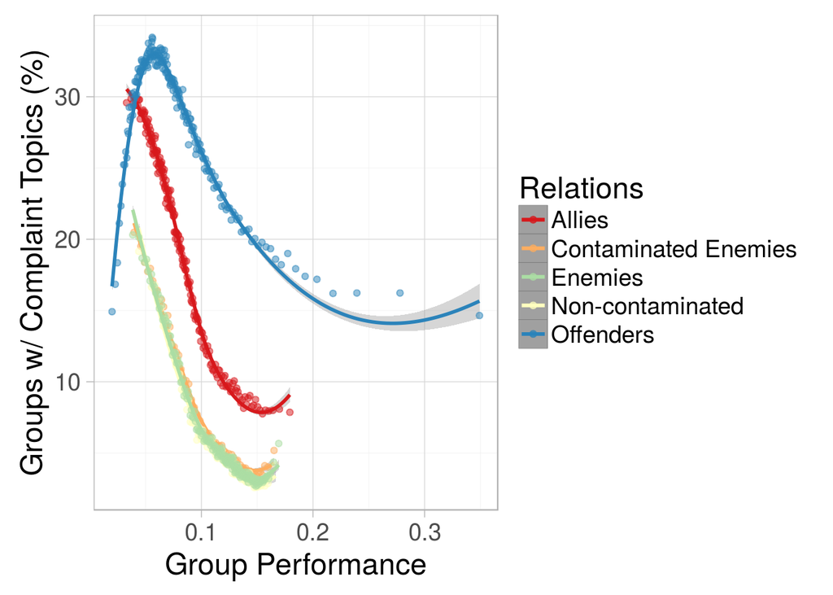

####Offender’s peak:

```
## [1] 0.0559267
```

```
## [1] 0.8739402
```

```
## [1] -0.9259598
```

#### Correlações:

```
## [1] "Aliados:"
## [1] -0.9591255
## [1] "Inimigos Contaminados:"
## [1] -0.9066414
## [1] "Não Contaminados:"
## [1] -0.8843088
## [1] "Inimigos Totais:"
## [1] -0.8820864
## [1] "Ofensor:"
## [1] -0.5048056
```

#### Comparisons:

Non-contaminated:

```
## [1] "mean/sd x"
## [1] 0.1041836
## [1] 0.03166442
## [1] "mean/sd y"
## [1] 0.1213482
## [1] 0.02616682
```

```
##
##  Welch Two Sample t-test
##
## data:  x and not_x
## t = -142.26, df = 77320, p-value < 2.2e-16
## alternative hypothesis: true difference in means is not equal to 0
## 95 percent confidence interval:
##  -0.01740105 -0.01692806
## sample estimates:
## mean of x mean of y
## 0.1041836 0.1213482
```

Contaminated enemies:

```
## [1] "mean/sd x"
## [1] 0.08755252
## [1] 0.03373041
## [1] "mean/sd y"
## [1] 0.1097983
## [1] 0.03362745
```

```
##
##  Welch Two Sample t-test
##
## data:  x and not_x
## t = -145.6, df = 62913, p-value < 2.2e-16
## alternative hypothesis: true difference in means is not equal to 0
## 95 percent confidence interval:
##  -0.02254523 -0.02194632
## sample estimates:
##  mean of x  mean of y
## 0.08755252 0.10979830
```

Allies:

```
## [1] "mean/sd x"
## [1] 0.07351362
## [1] 0.02574566
## [1] "mean/sd y"
## [1] 0.08697285
## [1] 0.03143763
```

```
##
##  Welch Two Sample t-test
##
## data:  x and not_x
## t = -277.03, df = 687200, p-value < 2.2e-16
## alternative hypothesis: true difference in means is not equal to 0
## 95 percent confidence interval:
##  -0.01355445 -0.01336401
## sample estimates:
##  mean of x  mean of y
## 0.07351362 0.08697285
```

Offenders:

```
## [1] "mean/sd x"
## [1] 0.07602465
## [1] 0.03678651
## [1] "mean/sd y"
## [1] 0.08427732
## [1] 0.04462411
```

```
##
##  Welch Two Sample t-test
##
## data:  x and not_x
## t = -132.08, df = 1232400, p-value < 2.2e-16
## alternative hypothesis: true difference in means is not equal to 0
## 95 percent confidence interval:
##  -0.008375141 -0.008130208
## sample estimates:
##  mean of x  mean of y
## 0.07602465 0.08427732
```

#### Comparisons in negative topics:

### Insults:

$(performance \approx 0.09)$

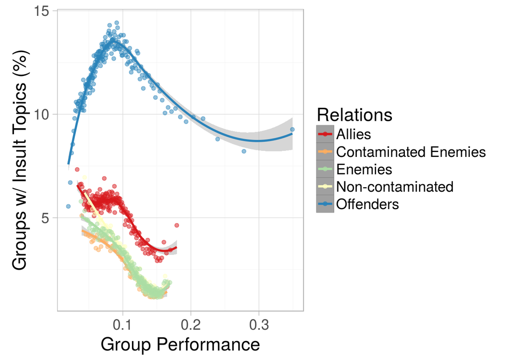

#### Correlações:

```
## [1] "Aliados:"
## [1] -0.4388466
## [1] "Inimigos Contaminados:"
## [1] -0.825512
## [1] "Não Contaminados:"
## [1] -0.8234762
## [1] "Inimigos Totais:"
## [1] -0.8313326
## [1] "Ofensor:"
## [1] 0.3087258
```

#### Offender’s peak

```
## [1] 0.0910003
```

```
## [1] 0.8134174
```

```
## [1] -0.8080494
```

#### Comparisons:

Non-contaminated:

```
## [1] "mean/sd x"
## [1] 0.1080204
## [1] 0.02999186
## [1] "mean/sd y"
## [1] 0.1207299
## [1] 0.02661796
```

```
##
##  Welch Two Sample t-test
##
## data:  x and not_x
## t = -75.988, df = 34139, p-value < 2.2e-16
## alternative hypothesis: true difference in means is not equal to 0
## 95 percent confidence interval:
##  -0.01303736 -0.01238170
## sample estimates:
## mean of x mean of y
## 0.1080204 0.1207299
```

Contaminated enemies:

```
## [1] "mean/sd x"
## [1] 0.09311682
## [1] 0.03321781
## [1] "mean/sd y"
## [1] 0.1083559
## [1] 0.03412522
```

```
##
##  Welch Two Sample t-test
##
## data:  x and not_x
## t = -57.951, df = 17309, p-value < 2.2e-16
## alternative hypothesis: true difference in means is not equal to 0
## 95 percent confidence interval:
##  -0.01575451 -0.01472365
## sample estimates:
##  mean of x  mean of y
## 0.09311682 0.10835590
```

Allies:

```
## [1] "mean/sd x"
## [1] 0.07997617
## [1] 0.02802309
## [1] "mean/sd y"
## [1] 0.08459258
## [1] 0.03100976
```

```
##
##  Welch Two Sample t-test
##
## data:  x and not_x
## t = -51.595, df = 119890, p-value < 2.2e-16
## alternative hypothesis: true difference in means is not equal to 0
## 95 percent confidence interval:
##  -0.004791779 -0.004441045
## sample estimates:
##  mean of x  mean of y
## 0.07997617 0.08459258
```

Offenders:

[output not shown]

[output not shown]

### Taunts:

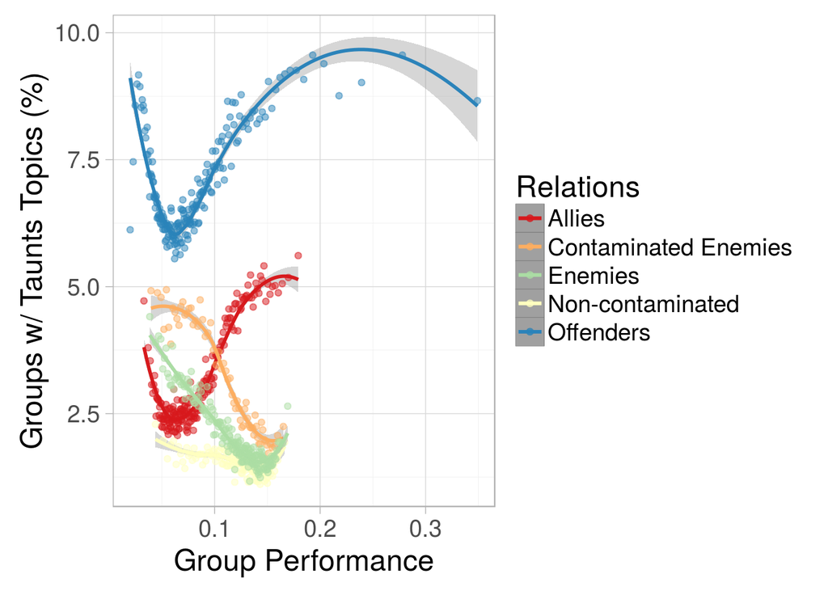

#### Correlações:

```
## [1] "Aliados:"
## [1] 0.5774775
## [1] "Inimigos Contaminados:"
## [1] -0.8124259
## [1] "Não Contaminados:"
## [1] -0.4600085
## [1] "Inimigos Totais:"
## [1] -0.715718
## [1] "Ofensor:"
## [1] 0.3243221
```

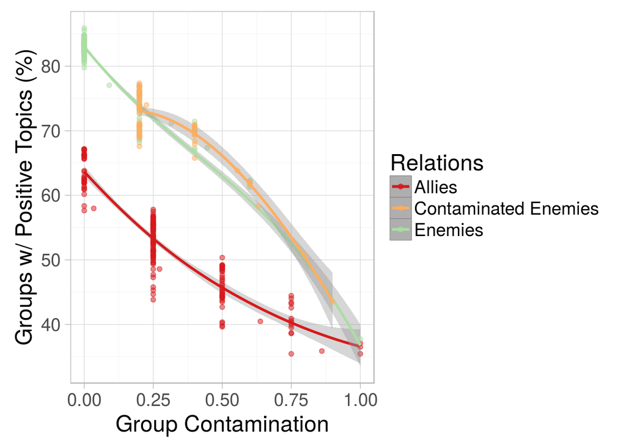

#### Correlações:

```
## [1] "Aliados:"
## [1] -0.7837376
## [1] "Inimigos Contaminados:"
## [1] -0.5400453
## [1] "Inimigos Totais:"
## [1] -0.6963913
```

### Tactics-related topics:

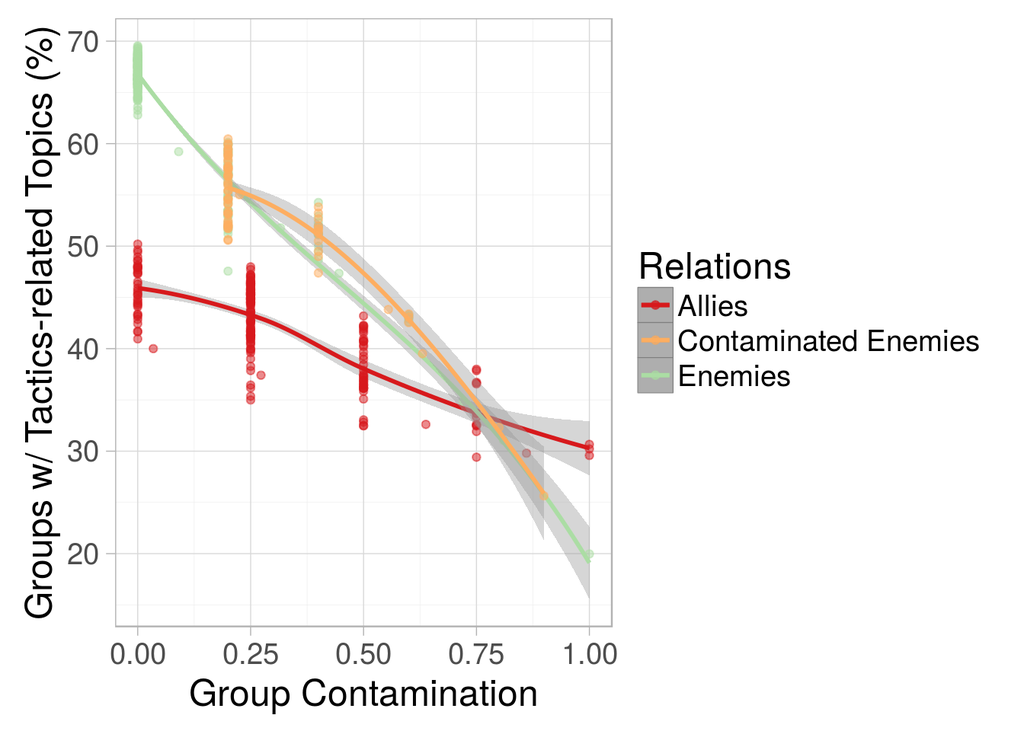

#### Correlações:

```
## [1] "Aliados:"
## [1] -0.5905795
## [1] "Inimigos Contaminados:"
## [1] -0.6062127
## [1] "Inimigos Totais:"
## [1] -0.701972
```

### Mood-related topics:

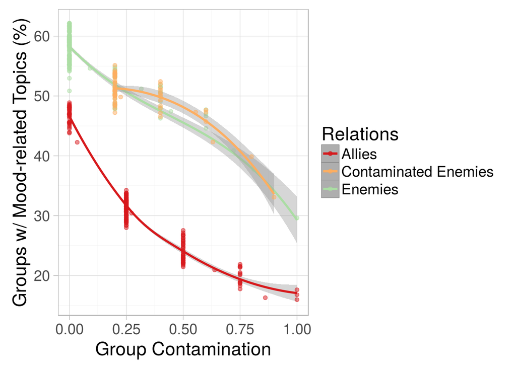

#### Correlações:

```
## [1] "Aliados:"
## [1] -0.8073669
## [1] "Inimigos Contaminados:"
## [1] -0.4471512
## [1] "Inimigos Totais:"
## [1] -0.6732689
```

#### Comparisons with other positive topics:

For enemies: (Comentado por enquanto, porque como mood tactics.full não são complementares, não faz sentido comparar ambos desta maneira) (Opções: comparar contra a média do grupo)

```r
# med.t.test(groups[relation.offender=='enemy' & (topic=='tactics.pos' | topic=='chit.chat') & topic.2=='pos']$contamination,
#                    groups[relation.offender=='enemy' & topic.2=='pos']$contamination)
```

For allies:

```r
# med.t.test(groups[relation.offender=='ally' & (topic=='tactics.pos' | topic=='chit.chat') & topic.2=='pos']$contamination,
#                    groups[relation.offender=='ally' & topic.2=='pos']$contamination)
```

### Negative topics:

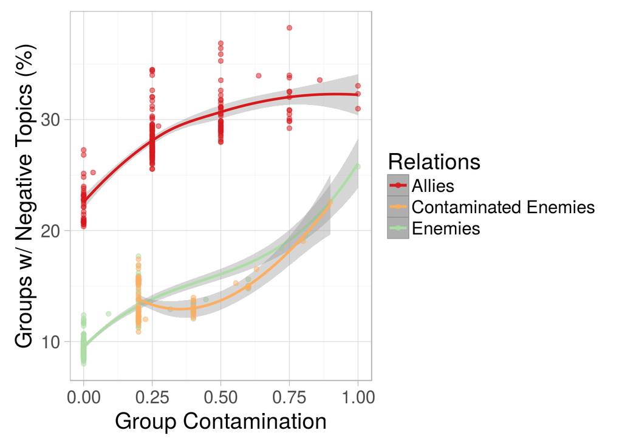

#### Correlações:

```
## [1] "Aliados:"
## [1] 0.6820146
## [1] "Inimigos Contaminados:"
## [1] 0.101632
## [1] "Inimigos Totais:"
## [1] 0.6422782
```

### Arguments topics:

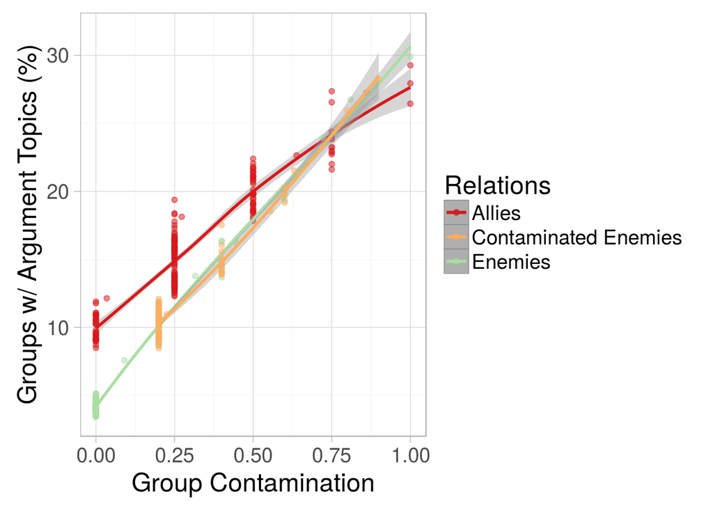

#### Correlações:

```
## [1] "Aliados:"
## [1] 0.8066422
## [1] "Inimigos Contaminados:"
## [1] 0.6829407
## [1] "Inimigos Totais:"
## [1] 0.7108803
```

#### Comparisons with other negative topics:

For enemies:

```r
med.t.test(groups[relation.offender=='enemy' & topic=='arguments']$contamination,
                     groups[relation.offender=='enemy' & topic!='arguments' & topic.2=='neg']$contamination)
```

```
## [1] "mean/sd x"
## [1] 0.1987384
## [1] 0.2218205
## [1] "mean/sd y"
## [1] 0.1244834
## [1] 0.1838908
```

```
##
##  Welch Two Sample t-test
##
## data:  x and not_x
## t = 102.64, df = 246390, p-value < 2.2e-16
## alternative hypothesis: true difference in means is not equal to 0
## 95 percent confidence interval:
##  0.07283701 0.07567292
## sample estimates:
## mean of x mean of y
## 0.1987384 0.1244834
```

For allies:

```r
med.t.test(groups[relation.offender=='ally' & topic=='arguments' & topic.2=='neg']$contamination,
                     groups[relation.offender=='ally' & topic!='arguments' & topic.2=='neg']$contamination)
```

```
## [1] "mean/sd x"
## [1] 0.3577638
## [1] 0.2312891
## [1] "mean/sd y"
## [1] 0.3211033
## [1] 0.2193493
```

```
##
##  Welch Two Sample t-test
##
## data:  x and not_x
## t = 71.852, df = 614400, p-value < 2.2e-16
## alternative hypothesis: true difference in means is not equal to 0
## 95 percent confidence interval:
##  0.03566056 0.03766061
## sample estimates:
## mean of x mean of y
## 0.3577638 0.3211033
```

### Complaints topics:

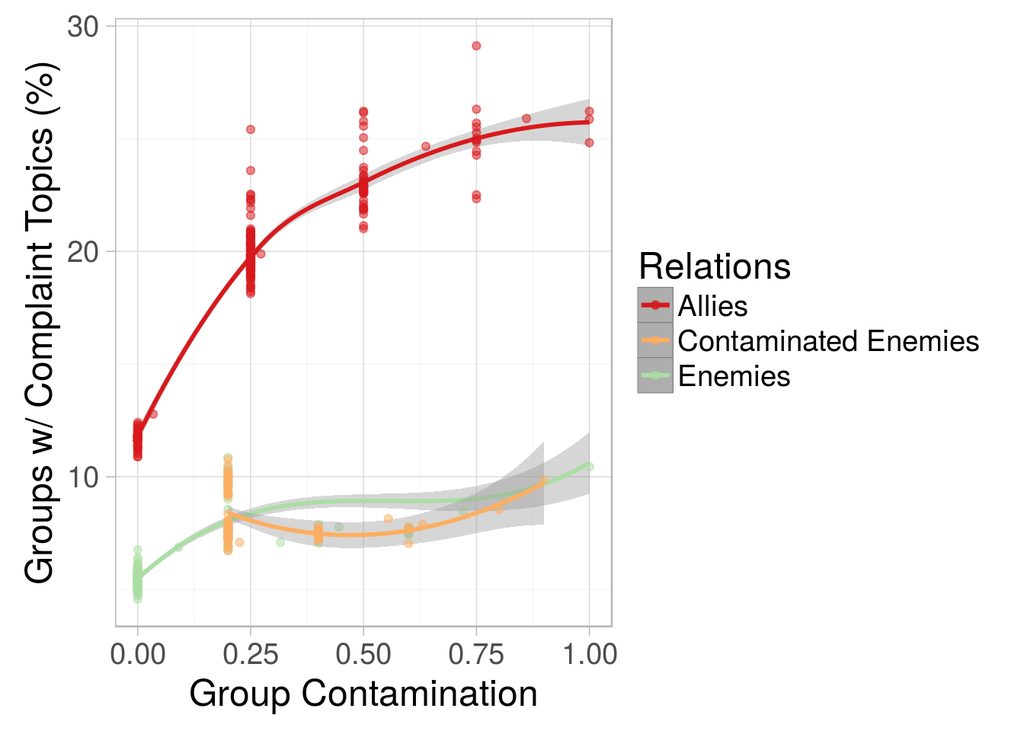

#### Correlações:

```
## [1] "Aliados:"
## [1] 0.7716947
## [1] "Inimigos Contaminados:"
## [1] -0.135509
## [1] "Inimigos Totais:"
## [1] 0.6241439
```

#### Comparisons with other negative topics:

For enemies:

```r
med.t.test(groups[relation.offender=='enemy' & topic=='complaints' & topic.2=='neg']$contamination,
                     groups[relation.offender=='enemy' & topic!='complaints' & topic.2=='neg']$contamination)
```

```
## [1] "mean/sd x"
## [1] 0.1205997
## [1] 0.1740065
## [1] "mean/sd y"
## [1] 0.1710732
## [1] 0.2147276
```

```
##
##  Welch Two Sample t-test
##
## data:  x and not_x
## t = -75.399, df = 303930, p-value < 2.2e-16
## alternative hypothesis: true difference in means is not equal to 0
## 95 percent confidence interval:
##  -0.05178557 -0.04916147
## sample estimates:
## mean of x mean of y
## 0.1205997 0.1710732
```

For allies:

```r
med.t.test(groups[relation.offender=='ally' & topic=='complaints' & topic.2=='neg']$contamination,
                     groups[relation.offender=='ally' & topic!='complaints' & topic.2=='neg']$contamination)
```

```
## [1] "mean/sd x"
## [1] 0.3418591
## [1] 0.2173112
## [1] "mean/sd y"
## [1] 0.328274
## [1] 0.2297852
```

```
##
##  Welch Two Sample t-test
##
## data:  x and not_x
## t = 28.066, df = 836210, p-value < 2.2e-16
## alternative hypothesis: true difference in means is not equal to 0
## 95 percent confidence interval:
##  0.01263634 0.01453375
## sample estimates:
## mean of x mean of y
## 0.3418591 0.3282740
```

### Insults topics:

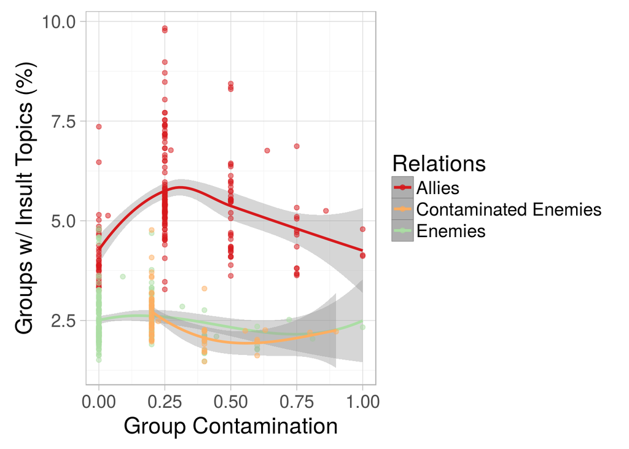

#### Correlações:

```
## [1] "Aliados:"
## [1] 0.1302296
## [1] "Inimigos Contaminados:"
## [1] -0.4359998
## [1] "Inimigos Totais:"
## [1] 0.001536159
```

#### Comparisons with other negative topics:

For enemies:

```r
med.t.test(groups[relation.offender=='enemy' & topic=='insults' & topic.2=='neg']$contamination,
                     groups[relation.offender=='enemy' & topic!='insults' & topic.2=='neg']$contamination)
```

```
## [1] "mean/sd x"
## [1] 0.09045306
## [1] 0.1539212
## [1] "mean/sd y"
## [1] 0.1633238
## [1] 0.2077017
```

```
##
##  Welch Two Sample t-test
##
## data:  x and not_x
## t = -92.153, df = 81759, p-value < 2.2e-16
## alternative hypothesis: true difference in means is not equal to 0
## 95 percent confidence interval:
##  -0.07442063 -0.07132088
## sample estimates:
##  mean of x  mean of y
## 0.09045306 0.16332381
```

For allies:

```r
med.t.test(groups[relation.offender=='ally' & topic=='insults' & topic.2=='neg']$contamination,
                     groups[relation.offender=='ally' & topic!='insults' & topic.2=='neg']$contamination)
```

```
## [1] "mean/sd x"
## [1] 0.3045667
## [1] 0.2041402
## [1] "mean/sd y"
## [1] 0.3384607
## [1] 0.2267876
```

```
##
##  Welch Two Sample t-test
##
## data:  x and not_x
## t = -49.677, df = 143410, p-value < 2.2e-16
## alternative hypothesis: true difference in means is not equal to 0
## 95 percent confidence interval:
##  -0.03523130 -0.03255677
## sample estimates:
## mean of x mean of y
## 0.3045667 0.3384607
```

### Taunts topics:

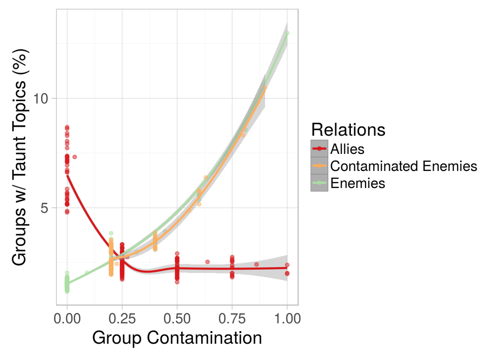

#### Correlações:

```
## [1] "Aliados:"
## [1] -0.4560991
## [1] "Inimigos Contaminados:"
## [1] 0.5918214
## [1] "Inimigos Totais:"
## [1] 0.7040565
```

#### Comparisons with other negative topics:

For enemies:

```r
med.t.test(groups[relation.offender=='enemy' & topic=='provoking' & topic.2=='neg']$contamination,
                     groups[relation.offender=='enemy' & topic!='provoking' & topic.2=='neg']$contamination)
```

```
## [1] "mean/sd x"
## [1] 0.1771033
## [1] 0.2291464
## [1] "mean/sd y"
## [1] 0.1498613
## [1] 0.1985721
```

```
##
##  Welch Two Sample t-test
##
## data:  x and not_x
## t = 22.958, df = 49558, p-value < 2.2e-16
## alternative hypothesis: true difference in means is not equal to 0
## 95 percent confidence interval:
##  0.02491623 0.02956769
## sample estimates:
## mean of x mean of y
## 0.1771033 0.1498613
```

For allies:

```r
med.t.test(groups[relation.offender=='ally' & topic=='provoking' & topic.2=='neg']$contamination,
                     groups[relation.offender=='ally' & topic!='provoking' & topic.2=='neg']$contamination)
```

```
## [1] "mean/sd x"
## [1] 0.2210173
## [1] 0.2266523
## [1] "mean/sd y"
## [1] 0.3431316
## [1] 0.221833
```

```
##
##  Welch Two Sample t-test
##
## data:  x and not_x
## t = -129.39, df = 71511, p-value < 2.2e-16
## alternative hypothesis: true difference in means is not equal to 0
## 95 percent confidence interval:
##  -0.1239641 -0.1202645
## sample estimates:
## mean of x mean of y
## 0.2210173 0.3431316
```

## Jogadores Contaminados vs. Não Contaminados

### Tópicos Positivos:

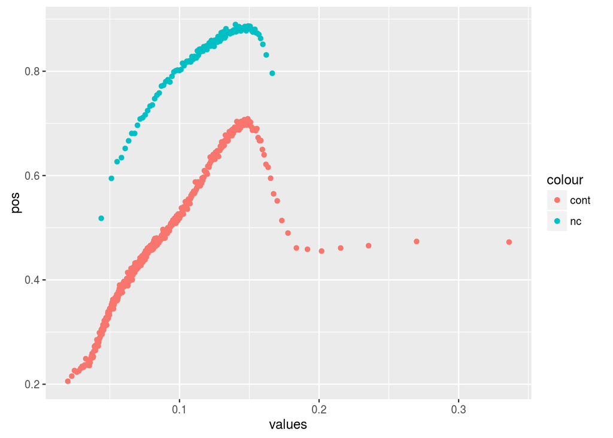

#### Correlações:

```
## [1] "Não Contaminados:"
```

```
## [1] 0.8046749
```

```
## [1] "Contaminados:"
```

```
## [1] 0.9280602
```

### Tópicos Negativos:

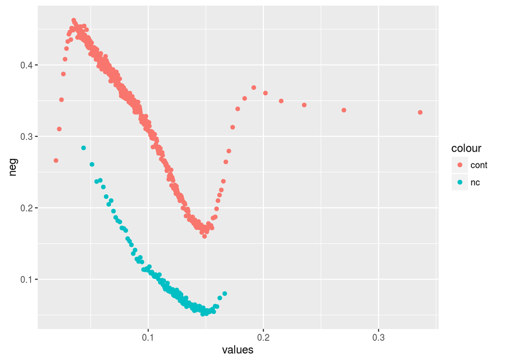

#### Correlações:

```
## [1] "Não Contaminados:"
```

```
## [1] -0.8778429
```

```
## [1] "Contaminados:"
```

```
## [1] -0.8905709
```

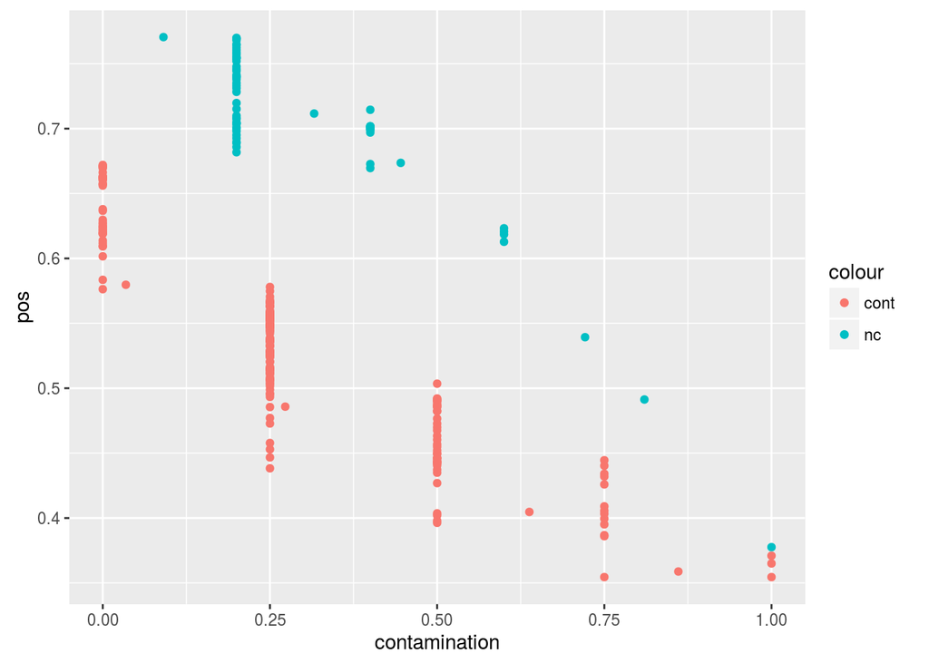

[figure not shown]

# Jogadores não contaminados x topicos do ofensor

Analyzing the topics used by the offender on contaminated and non-contaminated players, there is no significant difference between them. Offender targeting analysis may provide us with better anwsers about the motivations on the non-contamination of these groups.

Topics distribution for non-contaminated group aggregations

```r
prop.table(summary(matches[enemy.contamination == 0]$offender.groups))
```

```
##   arguments   chit.chat  complaints     insults other.langs   provoking
##  0.13728160  0.07946322  0.30250999  0.13286795  0.03045161  0.05239064
##     tactics tactics.pos        NA's
##  0.16228418  0.08065595  0.02209487
```

Topics distribution for all group aggregations.

```r
prop.table(summary(matches$offender.groups))
```

```
##   arguments   chit.chat  complaints     insults other.langs   provoking
##  0.14708260  0.09423955  0.28180649  0.12040642  0.02761634  0.07046894
##     tactics tactics.pos        NA's
##  0.15325838  0.08225722  0.02286405
```

## TODO: Contaminação x performance global(aliados e inimigos)

Differences between non-contaminated contamination mean(should be zero) and contaminated players contamination mean.

```r
med.t.test(groups[relation.offender=='enemy' & contamination == 0]$contamination, groups[relation.offender!='enemy' | contamination > 0]$contamination)
```

```
## [1] "mean/sd x"
## [1] 0
## [1] 0
## [1] "mean/sd y"
## [1] 0.2965154
## [1] 0.2048609
```

```
##
##  Welch Two Sample t-test
##
## data:  x and not_x
## t = -2339, df = 2611500, p-value < 2.2e-16
## alternative hypothesis: true difference in means is not equal to 0
## 95 percent confidence interval:
##  -0.2967639 -0.2962670
## sample estimates:
## mean of x mean of y
## 0.0000000 0.2965154
```

Differences between ally and enemy contamination means.

```r
med.t.test(matches$ally.contamination, matches$enemy.contamination)
```

```
## [1] "mean/sd x"
## [1] 0.2999964
## [1] 0.2185822
## [1] "mean/sd y"
## [1] 0.09437879
## [1] 0.1614736
```

```
##
##  Welch Two Sample t-test
##
## data:  x and not_x
## t = 1060.2, df = 3614700, p-value < 2.2e-16
## alternative hypothesis: true difference in means is not equal to 0
## 95 percent confidence interval:
##  0.2052375 0.2059978
## sample estimates:
##  mean of x  mean of y
## 0.29999643 0.09437879
```

Correlation between contamination and performance for all groups.

```r
cor.test(groups$contamination, groups$performance, method='spearman')
```

```
##
##  Spearman's rank correlation rho
##
## data:  groups$contamination and groups$performance
## S = 1.4474e+19, p-value < 2.2e-16
## alternative hypothesis: true rho is not equal to 0
## sample estimates:
##        rho
## -0.4340339
```

# Relacionar contaminação com a presença do ofensor no ‘all chat’

```r
med.t.test(matches[offender.all == 0]$enemy.contamination, matches[offender.all > 0]$enemy.contamination)
```

```
## [1] "mean/sd x"
## [1] 0.05000988
## [1] 0.1158038
## [1] "mean/sd y"
## [1] 0.1083691
## [1] 0.171027
```

```
##
##  Welch Two Sample t-test
##
## data:  x and not_x
## t = -266.14, df = 1166800, p-value < 2.2e-16
## alternative hypothesis: true difference in means is not equal to 0
## 95 percent confidence interval:
##  -0.05878901 -0.05792944
## sample estimates:
##  mean of x  mean of y
## 0.05000988 0.10836911
```

```r
med.t.test(matches[offender.all == 0]$ally.contamination, matches[offender.all > 0]$ally.contamination)
```

```
## [1] "mean/sd x"
## [1] 0.3180026
## [1] 0.195484
## [1] "mean/sd y"
## [1] 0.2943188
## [1] 0.2250766
```

```
##
##  Welch Two Sample t-test
##
## data:  x and not_x
## t = 69.803, df = 897030, p-value < 2.2e-16
## alternative hypothesis: true difference in means is not equal to 0
## 95 percent confidence interval:
##  0.02301881 0.02434882
## sample estimates:
## mean of x mean of y
## 0.3180026 0.2943188
```

# Alvos do ofensor em certos tópicos negativos

Foi mostrado que o topico de insultos afetam primariamente os jogadores aliados, e o tópico de provocações, os jogadores inimigos. Hipotetizamos que isso ocoreu porque o time aliado é o principal alvo do ofensor no caso de insultos, e o time inimigo no caso de provocações. Podemos verificar quem o jogador ofensor está alvejando a partir do uso dos canais de chat pelo mesmo. Como o canal ‘all’ é a única maneira do ofensor entrar em contato com o time inimigo, atividade neste implica que o ofensor está comunicando-se com o time inimigo. Para evitar distorções devido a partidas mais longas tenderem a possuir mais uso dos chats, medimos a atividade nos canais usando postagens por minuto.

## Insults

Podemos ver que a média da atividade do ofensor no canal ‘all’ quando este predominantemente insulta $(mean=0.20)$ é menor do que a média de atividade na predominância de outros tópicos $(mean=0.32)$. Isso mostra que o ofensor dá menos atenção ao grupo inimigo em casos de insulto. Não temos confirmação de que o ofensor foca seus ataques no grupo aliado através da atividade no chat. Contudo, analisando as palavras utilizadas pelo ofensor e a relação entre a quantidade de insultos realizadas pelo ofensor e a contaminação, fica claro que o time aliado é consideravelmente afetado por estes insultos.

```r
x <- matches[offender.groups=='insults']$offender.all
not.x <- matches[offender.groups!='insults']$offender.all
t.test(x,not.x)
```

```
##
##  Welch Two Sample t-test
##
## data:  x and not.x
## t = -115.85, df = 432660, p-value < 2.2e-16
## alternative hypothesis: true difference in means is not equal to 0
## 95 percent confidence interval:
##  -0.1237800 -0.1196616
## sample estimates:
## mean of x mean of y
## 0.1993550 0.3210758
```

```r
x <- matches[offender.groups=='insults']$offender.team
not.x <- matches[offender.groups!='insults']$offender.team
t.test(x,not.x)
```

```
##
##  Welch Two Sample t-test
##
## data:  x and not.x
## t = -58.656, df = 372260, p-value < 2.2e-16
## alternative hypothesis: true difference in means is not equal to 0
## 95 percent confidence interval:
##  -0.1136733 -0.1063222
## sample estimates:
## mean of x mean of y
## 0.8958369 1.0058346
```

## Taunts

A média da atividade do ofensor no canal ‘all’ quando este predominantemente provoca $(mean=0.45)$, é significativamente superior $(p < 2.2*10^{16})$ a média da atividade do ofensor no ‘all’ quando outros tópicos são predominantes $(mean=0.29)$. isso mostra que em casos de provocação, o ofensor foca no time inimigo em detrimento do time aliado, que mostra atividade significativamente mais baixa $(p < 2.2*10^{16})$ por parte do ofensor em casos onde provocação é predominante $(mean=0.68)$ do que em outros casos $(mean=1.01)$.

```r
x <- matches[offender.groups=='provoking']$offender.all
not.x <- matches[offender.groups!='provoking']$offender.all
t.test(x,not.x)
```

```
##
##  Welch Two Sample t-test
##
## data:  x and not.x
## t = 35.775, df = 140500, p-value < 2.2e-16
## alternative hypothesis: true difference in means is not equal to 0
## 95 percent confidence interval:
##  0.1526535 0.1703497
## sample estimates:
## mean of x mean of y
## 0.4559313 0.2944297
```

```r
x <- matches[offender.groups=='provoking']$offender.team
not.x <- matches[offender.groups!='provoking']$offender.team
t.test(x,not.x)
```

```
##
##  Welch Two Sample t-test
##
## data:  x and not.x
## t = -53.937, df = 141710, p-value < 2.2e-16
## alternative hypothesis: true difference in means is not equal to 0
## 95 percent confidence interval:
##  -0.3486237 -0.3241753
## sample estimates:
## mean of x mean of y
## 0.6801412 1.0165407
```

Podemos replicar esse experimento para os tópicos negativos restantes:

## Complaints

Diferença estatisticamente significativa em ambos, logo, consideramos que houve um ‘empate técnico’. Contudo, a diferença real no ‘team’ é bem significativa $mean=1.11$ para grupos com complaints, $mean=0.95$ para grupos sem complaints. Isso significa que ofensores que reclamam alvejam o time aliado mais do que o normal.

```r
x <- matches[offender.groups=='complaints']$offender.all
not.x <- matches[offender.groups!='complaints']$offender.all
t.test(x,not.x)
```

```
##
##  Welch Two Sample t-test
##
## data:  x and not.x
## t = 6.5847, df = 1575600, p-value = 4.558e-11
## alternative hypothesis: true difference in means is not equal to 0
## 95 percent confidence interval:
##  0.004174234 0.007712285
## sample estimates:
## mean of x mean of y
## 0.3103061 0.3043628
```

```r
x <- matches[offender.groups=='complaints']$offender.team
not.x <- matches[offender.groups!='complaints']$offender.team
t.test(x,not.x)
```

```
##
##  Welch Two Sample t-test
##
## data:  x and not.x
## t = 106.71, df = 1313700, p-value < 2.2e-16
## alternative hypothesis: true difference in means is not equal to 0
## 95 percent confidence interval:
##  0.1608507 0.1668698
## sample estimates:
## mean of x mean of y
## 1.1088832 0.9450229
```